# Análisis de chiste

Jun De Wu

09/05/2021

# 1 Lectura de los datos

Empezamos por cargar los paquetes que utilizaremos durante todo el documento.

```r
require(tidyverse)
require(tidytext)
require(tm)
require(splitstackshape)
require(forcats)
require(topicmodels)
```

El archivo `csv` que contiene los datos de los chistes es `chistes.csv` y los guardaremos en la variable `chistes_raw`.

```r
chistes_raw <- read_csv("chistes.csv", col_names = TRUE)
anyNA(chistes_raw)
```

```
## [1] TRUE
```

Veamos qué columnas contienen NA’s.

```r
which(is.na(chistes_raw$origin))
```

```
## integer(0)
```

```r
which(is.na(chistes_raw$title))
```

```
## [1] 2631
```

```r
which(is.na(chistes_raw$categories))
```

```
##  [1]  414  459  875 2740 3329 3449 5135 5844 6560 6887
```

```r
which(is.na(chistes_raw$text))
```

```
## [1] 2740 3329 3449 5135 5844 6560 6887
```

Eliminamos las filas 414, 459, 875, 2631, 2740, 3329, 3449, 5135, 5844, 6560 y 6887 que tienen NA’s que afectan a nuestro conjunto de datos.

```r
chistes_raw <- chistes_raw[-c(414, 459, 875, 2631, 2740, 3329, 3449, 5135, 5844, 6560, 6887),]
```

A continuación declararemos dos nuevas variables que contendrán los chistes de Pintamania y 1000 chistes por separado después de haber limpiado un poco los datos.

```r
pintamania <- chistes_raw %>%
  filter(origin == "Pintamania")

mil_chistes <- chistes_raw %>%
  filter(origin == "1000 chistes")
```

Estos dos conjuntos de datos son los que nosotros utilizaremos para el desarrollo del proyecto.

# 2 Generación del corpus y limpieza de los datos

Para poder generar el corpus primero tenemos que pasar los data sets de tal forma que tengan como argumentos `doc_id` y `text`. Juntaremos los textos de las columnas `title`, `origin`, `categories` y `tags` dentro de la nueva columna `doc_id` separándolos por “####” para poder guardar la información de los conjuntos originales.

```r
pintamania_1 <- pintamania %>%
  mutate(doc_id = paste(title, origin, categories, tags, sep = "####")) %>%
  select(doc_id, text)

mil_chistes_1 <- mil_chistes %>%
  mutate(doc_id = paste(title, origin, categories, tags, sep = "####")) %>%
  select(doc_id, text)
```

Una vez que tenemos los conjuntos `pintamania_1` y `mil_chistes_1` ya podemos generar el corpus de cada caso.

```r
corpus_pint <- VCorpus(DataframeSource(pintamania_1), readerControl = list(language = "es"))
corpus_mil <- VCorpus(DataframeSource(mil_chistes_1), readerControl = list(language = "es"))
```

Una vez generados los corpus realizamos la limpieza para ambos casos. En los dos casos quitaremos los stopwords, los puntos y comas, los números, los espacios en blanco extras, pasaremos las letras mayúsculas a minúsculas y quitaremos los símbolos “-, /, ?, ¿, ¡, !”.

```r
toSpace = function(rx) tm::content_transformer(function(s) gsub(rx, ' ', s))
```

```r
corpus_pint <- tm_map(corpus_pint, removePunctuation)
corpus_pint <- tm_map(corpus_pint, removeWords, stopwords("spanish"))
corpus_pint <- tm_map(corpus_pint, removeNumbers)
corpus_pint <- tm_map(corpus_pint, stripWhitespace)
corpus_pint <- tm_map(corpus_pint, content_transformer(tolower))
corpus_pint <- tm_map(corpus_pint, toSpace('[-/?¿¡!-_–].'))

corpus_pint
```

```
## <<VCorpus>>
## Metadata:  corpus specific: 0, document level (indexed): 0
## Content:  documents: 4742
```

```r
corpus_mil <- tm_map(corpus_mil, removePunctuation)
corpus_mil <- tm_map(corpus_mil, removeWords, stopwords("spanish"))
corpus_mil <- tm_map(corpus_mil, removeNumbers)
corpus_mil <- tm_map(corpus_mil, stripWhitespace)
corpus_mil <- tm_map(corpus_mil, content_transformer(tolower))
corpus_mil <- tm_map(corpus_mil, toSpace('[-/?¿¡!-_–]'))

corpus_mil
```

```
## <<VCorpus>>
## Metadata:  corpus specific: 0, document level (indexed): 0
## Content:  documents: 2419
```

# 3 TF-IDF por chiste

El tf-idf (Term frequency times Inverse document frequency) es una cantidad usada para identificar terminos que son especialmente importantes para un documento en particular. Tenemos que generar para cada corpus su Document Term Matrix, para más adelante pasarlo a formato tidy. Con este tidy usaremos la función `bind_tf_idf` que nos dará la matriz con los tf-idf de cada palabra.

```r
dt_pint <- DocumentTermMatrix(corpus_pint)
pint_tidy <- tidy(dt_pint)

pint_tf_idf <- pint_tidy %>%
  bind_tf_idf(document, term, count)

dt_mil <- DocumentTermMatrix(corpus_mil)
mil_tidy <- tidy(dt_mil)

mil_tf_idf <- mil_tidy %>%
  bind_tf_idf(document, term, count)
```

Recordamos que en la identificación de cada chiste hemos puesto el origen, el título, las categorías y los tags, separados por “####”. Es hora poner cada característica como una columna y eso lo haremos con la función `cSplit` del paquete `splitstackshape`.

```r
pint_tf_idf <- pint_tf_idf %>%
  cSplit("document", "####") %>%
  rename(title = document_1, origin = document_2,
         categories = document_3, tags = document_4) %>%
  select(title, origin, term, tf_idf, categories, tags)

mil_tf_idf <- mil_tf_idf %>%
  cSplit("document", "####") %>%
  rename(title = document_1, origin = document_2,
         categories = document_3, tags = document_4) %>%
  select(title, origin, term, tf_idf, categories, tags)
```

Vamos a visualizar las palabras con alto índice de tf-idf de cada conjunto. Hay muchísimos chistes, por lo tanto lo haremos con los 4 primeros chistes de cada caso. En el data frame de tf-idf de los chistes de pintamania, los 4 primeros chistes van de la fila 1 hasta la fila 21; en cambio, los 4 primeros chistes de 1000 chistes van de la fila 1 hasta la fila 60.

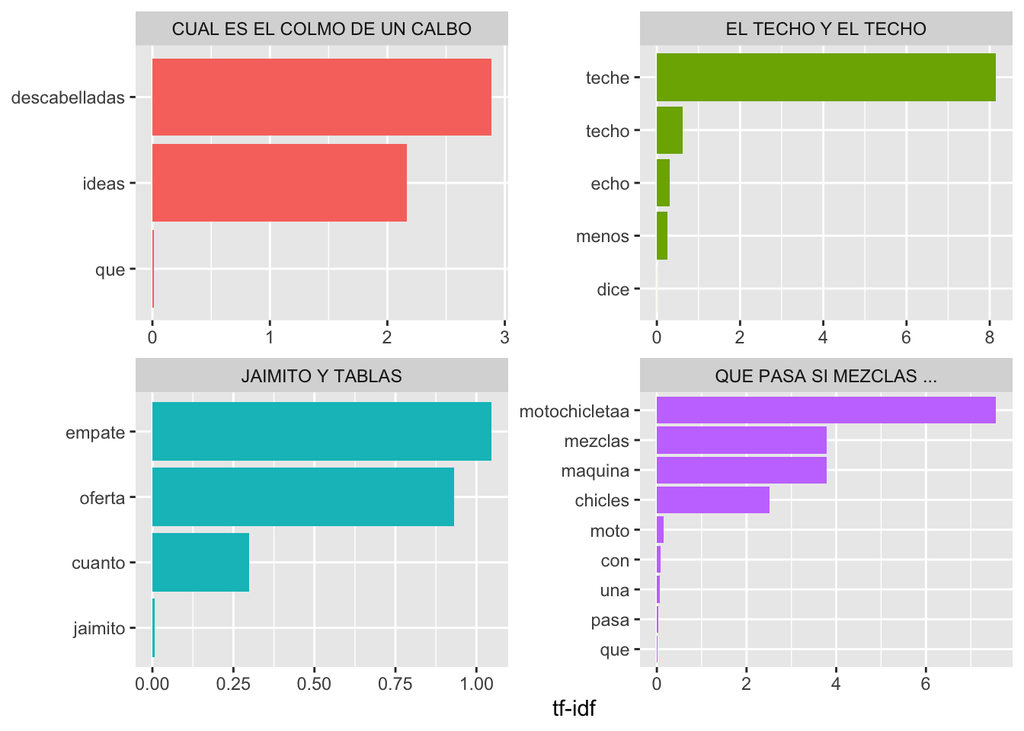

```r
pint_tf_idf %>%
  slice(1:21) %>%
  group_by(title) %>%
  slice_max(tf_idf, n = 15) %>%
  ungroup() %>%
  ggplot(aes(tf_idf, fct_reorder(term, tf_idf), fill = title)) + geom_col(show.legend = FALSE) +
  facet_wrap(~title, ncol = 2, scales = "free") +
  labs(x = "tf-idf", y = NULL)
```

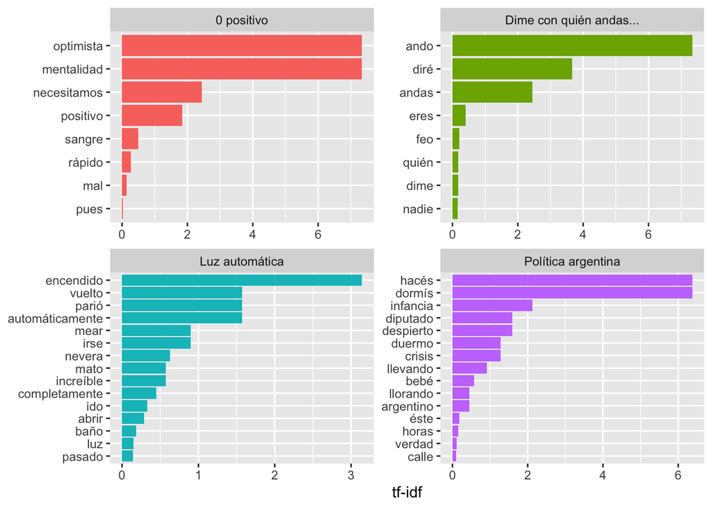

```r
mil_tf_idf %>%
  slice(1:60) %>%
  group_by(title) %>%
  slice_max(tf_idf, n = 15) %>%
  ungroup() %>%
  ggplot(aes(tf_idf, fct_reorder(term, tf_idf), fill = title)) + geom_col(show.legend = FALSE) +
  facet_wrap(~title, ncol = 2, scales = "free") +
  labs(x = "tf-idf", y = NULL)
```

# 4 Document Term Matrix (DTM) entre las dos webs

En el apartado anterior ya hemos realizado los dtm de cada conjunto de datos (`dt_pint` y `dt_mil`), pero hay que hacer unos pequeños ajustes para el último apartado.

```r
mil_dtm <- mil_tf_idf %>%
  count(title, term) %>%
  cast_dtm(title, term, n)
mil_dtm
```

```
## <<DocumentTermMatrix (documents: 2396, terms: 12308)>>
## Non-/sparse entries: 49821/29440147
## Sparsity           : 100%
## Maximal term length: 32
## Weighting          : term frequency (tf)
```

```r
pint_dtm <- pint_tf_idf %>%
  count(title, term) %>%
  cast_dtm(title, term, n)
pint_dtm
```

```
## <<DocumentTermMatrix (documents: 3612, terms: 17282)>>
## Non-/sparse entries: 62248/62360336
## Sparsity           : 100%
## Maximal term length: 143
## Weighting          : term frequency (tf)
```

# 5 Latent Dirichlet allocation (LAD) topic models

LDA es un método particularmente popular para ajustar un topic models. Con `mil_dtm` y `pint_dtm` podemos pasar un LDA topic models para cada data set. Seleccionaremos 10 topics al aplicar la función `LDA` (k = 10).

```r
pint_lda <- LDA(pint_dtm, k = 10, control = list(seed = 284))
```

```r
mil_lda <- LDA(mil_dtm, k = 10, control = list(seed = 284))
```

Usamos la función `tidy` para sacar las probabilidad de cada palabra por cada tema, llamado también $\beta$, del modelo.

```r
pint_topics <- tidy(pint_lda, matrix = "beta")
pint_topics
```

```
## # A tibble: 172,820 x 3
##    topic term           beta
##    <int> <chr>         <dbl>
##  1     1 amarganaa 6.52e-267
##  2     2 amarganaa 9.12e-266
##  3     3 amarganaa 6.64e-265
##  4     4 amarganaa 6.18e- 15
##  5     5 amarganaa 1.83e-265
##  6     6 amarganaa 2.66e-254
##  7     7 amarganaa 5.71e-268
##  8     8 amarganaa 1.65e-259
##  9     9 amarganaa 2.08e-273
## 10    10 amarganaa 1.72e-  4
## # … with 172,810 more rows
```

```r
mil_topics <- tidy(mil_lda, matrix = "beta")
mil_topics
```

```
## # A tibble: 123,080 x 3
##    topic term       beta
##    <int> <chr>     <dbl>
##  1     1 adiós 9.34e-299
##  2     2 adiós 1.61e-114
##  3     3 adiós 3.41e-  4
##  4     4 adiós 1.30e- 74
##  5     5 adiós 1.58e- 74
##  6     6 adiós 1.92e- 74
##  7     7 adiós 3.86e-268
##  8     8 adiós 1.76e- 74
##  9     9 adiós 9.76e-270
## 10    10 adiós 2.07e-  4
## # … with 123,070 more rows
```

Podemos usar la función `top_n` del paquete `dplyr`, que está incluido en el conjunto de paquetes `tidyverse`, para los 10 términos más comunes dentro de cada tema.

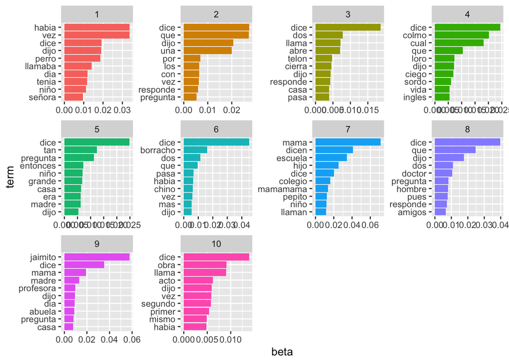

```r
pint_top_terms <- pint_topics %>%
  group_by(topic) %>%
  top_n(10, beta) %>%
  ungroup() %>%
  arrange(topic, -beta)

pint_top_terms %>%
  mutate(term = reorder_within(term, beta, topic)) %>%
  ggplot(aes(beta, term, fill = factor(topic))) +
  geom_col(show.legend = FALSE) +
  facet_wrap(~ topic, scales = "free") +
  scale_y_reordered()
```

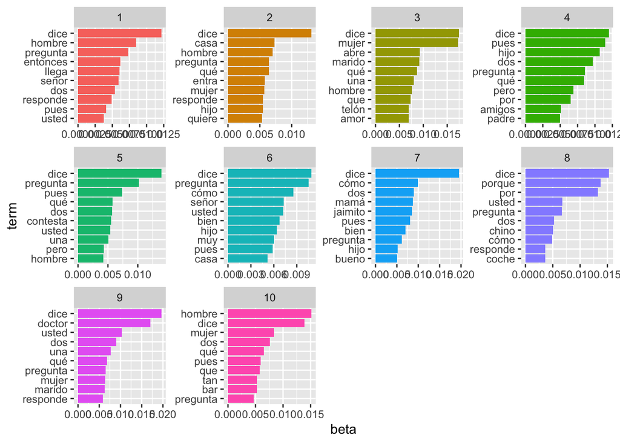

```r
mil_top_terms <- mil_topics %>%
  group_by(topic) %>%
  top_n(10, beta) %>%
  ungroup() %>%
  arrange(topic, -beta)

mil_top_terms %>%
  mutate(term = reorder_within(term, beta, topic)) %>%
  ggplot(aes(beta, term, fill = factor(topic))) +
  geom_col(show.legend = FALSE) +
  facet_wrap(~ topic, scales = "free") +
  scale_y_reordered()
```

Una vez visualizadas las palabras que tienen mayor $\beta$ en cada tema, veamos cómo podemos relacionar las palabras de cada chiste con las categorías.

Empezamos por clasificar cada palabra en un único tema. Cada palabra tiene un índice $\beta$ correspondiente a cada tema, asignaremos que una palabra está dentro del tema si tiene el valor $\beta$ más grande de todos.

```r
pint_topics_words <- pint_topics %>%
  group_by(term) %>%
  filter(beta == max(beta))

pint_topics_words
```

```
## # A tibble: 17,282 x 3
## # Groups:   term [17,282]
##    topic term          beta
##    <int> <chr>        <dbl>
##  1    10 amarganaa 0.000172
##  2    10 azucar    0.00120
##  3     6 cafe      0.00131
##  4     6 dice      0.0450
##  5    10 loko      0.000172
##  6     4 seria     0.000553
##  7    10 sin       0.000635
##  8    10 ver       0.00312
##  9     4 vida      0.00550
## 10     2 ale       0.000297
## # … with 17,272 more rows
```

```r
mil_topics_words <- mil_topics %>%
  group_by(term) %>%
  filter(beta == max(beta))

mil_topics_words
```

```
## # A tibble: 12,308 x 3
## # Groups:   term [12,308]
##    topic term         beta
##    <int> <chr>       <dbl>
##  1     3 adiós    0.000341
##  2    10 bar      0.00527
##  3     1 borracho 0.00280
##  4     7 cállate  0.000772
##  5     4 calle    0.00317
##  6     9 camina   0.000368
##  7     5 contesta 0.00553
##  8     1 cruza    0.000478
##  9    10 fea      0.00235
## 10     3 gira     0.000341
## # … with 12,298 more rows
```

Para tener incluida la categoría, vamos a juntar ambas cosas con la función `merge`.

```r
pint_top_cat <- merge(pint_topics_words, pint_tf_idf, by = "term")

mil_top_cat <- merge(mil_topics_words, mil_tf_idf, by = "term")
```

Veamos qué tipo de chistes predominan en ambos conjuntos. Cogeremos los 10 primeros.

Empezamos por los chistes de pintamania.

```r
head(sort(table(pint_top_cat$categories), decreasing = TRUE), 10)
```

```
##
##       Chistes variados     Chistes de Jaimito   Chistes de mamá mamá
##                  21020                  11620                   9571
##    Chistes de animales      Chistes de amigos   Chistes de borrachos
##                   8731                   5813                   3134
##         Chistes cortos Chistes de informática   Chistes de marineros
##                    672                    589                    546
##    Chistes de deportes
##                    253
```

Seguimos con los chistes de 1000 chistes.

```r
head(sort(table(mil_top_cat$categories), decreasing = TRUE), 10)
```

```
##
##           cortos|malos          largos|buenos          cortos|buenos
##                   3853                   1754                   1108
##                 buenos                 cortos          buenos|largos
##                    916                    863                    542
##        internacionales            matrimonios animales|largos|buenos
##                    533                    497                    472
##                 verdes
##                    428
```

En este caso tenemos categorías cruzadas, pero nos quedamos con las categorías “cortos”, “malos”, “largos”, “buenos”, “internacionales”, “matrimonios”, “animales” y “verdes”.

Lo siguiente que haremos será, para cada conjunto de datos, dos tablas de contingencia compuesta por los temas y las categorías seleccionadas. Empezamos por pintamania.

```r
variados <- pint_top_cat %>%
  filter(grepl('Chistes variados', categories)) %>%
  mutate(categories = "Chistes variados")

jaimito <- pint_top_cat %>%
  filter(grepl('Chistes de Jaimito', categories)) %>%
  mutate(categories = "Chistes de Jaimito")

mama <- pint_top_cat %>%
  filter(grepl('Chistes de mamá mamá', categories)) %>%
  mutate(categories = "Chistes de mamá mamá")

animales <- pint_top_cat %>%
  filter(grepl('Chistes de animales', categories)) %>%
  mutate(categories = "Chistes de animales")

amigos <- pint_top_cat %>%
  filter(grepl('Chistes de amigos', categories)) %>%
  mutate(categories = "Chistes de amigos")

borrachos <- pint_top_cat %>%
  filter(grepl('Chistes de borrachos', categories)) %>%
  mutate(categories = "Chistes de borrachos")

cortos <- pint_top_cat %>%
  filter(grepl('Chistes cortos', categories)) %>%
  mutate(categories = "Chistes cortos")

informatica <- pint_top_cat %>%
  filter(grepl('Chistes de informática', categories)) %>%
  mutate(categories = "Chistes de informática")

marineros <- pint_top_cat %>%
  filter(grepl('Chistes de marineros', categories)) %>%
  mutate(categories = "Chistes de marineros")

deportes <- pint_top_cat %>%
  filter(grepl('Chistes de deportes', categories)) %>%
  mutate(categories = "Chistes de deportes")

mat_conf_pint <- rbind(variados, jaimito, mama, animales, amigos, borrachos, cortos, informatica,
                       marineros, deportes)
table(mat_conf_pint$categories, mat_conf_pint$topic, dnn = c("CATEGORÍAS", "TEMAS"))
```

```
##                         TEMAS
## CATEGORÍAS                 1    2    3    4    5    6    7    8    9   10
##   Chistes cortos           53   69   49   49  105  148   63   49   32   55
##   Chistes de amigos       776  605  582  492  463  837  474  652  323  609
##   Chistes de animales    1596 1041  610 1358  710  951  450  608  308 1099
##   Chistes de borrachos    346  274  280  157  239  996  169  246  157  270
##   Chistes de deportes      27   24   55    2   45   30   13   24   16   17
##   Chistes de informática   44   87   54   41   52   68   47   88   21   87
##   Chistes de Jaimito     1125  857  445  570 1120 1115 1475  699 3550  664
##   Chistes de mamá mamá    781  762  554  478  783  805 3242  640  839  687
##   Chistes de marineros     84   51   38   62   41   36   56   53   67   58
##   Chistes variados       2261 2365 1969 2120 2278 2958 1452 2125 1116 2376
```

Realizamos el mismo procedimiento pero con los chistes de 1000 chistes.

```r
cortos <- mil_top_cat %>%
  filter(grepl('cortos', categories)) %>%
  mutate(categories = "cortos")

malos <- mil_top_cat %>%
  filter(grepl('malos', categories)) %>%
  mutate(categories = "malos")

largos <- mil_top_cat %>%
  filter(grepl('largos', categories)) %>%
  mutate(categories = "largos")

buenos <- mil_top_cat %>%
  filter(grepl('buenos', categories)) %>%
  mutate(categories = "buenos")

internacionales <- mil_top_cat %>%
  filter(grepl('internacionales', categories)) %>%
  mutate(categories = "internacionales")

matrimonios <- mil_top_cat %>%
  filter(grepl('matrimonios', categories)) %>%
  mutate(categories = "matrimonios")

animales <- mil_top_cat %>%
  filter(grepl('animales', categories)) %>%
  mutate(categories = "animales")

verdes <- mil_top_cat %>%
  filter(grepl('verdes', categories)) %>%
  mutate(categories = "verdes")

mat_conf_mil <- rbind(buenos, cortos, largos, malos, internacionales, matrimonios, animales, verdes)
table(mat_conf_mil$categories, mat_conf_mil$topic, dnn = c("CATEGORÍAS", "TEMAS"))
```

```
##                  TEMAS
## CATEGORÍAS          1    2    3    4    5    6    7    8    9   10
##   animales         569  714  520  610  587  507  433  477  506  788
##   buenos          2216 1900 1982 1862 1598 2062 1843 1817 1986 1935
##   cortos          1416 1576 2465 2279 1483 1319 1825 1566 1790 1813
##   internacionales  141  103  217  204  262  210  188  297  179  121
##   largos          1553 1175 1061 1059 1091 1374 1077 1110 1027 1251
##   malos            967 1103 1435 1359 1073  845 1153  946 1127 1165
##   matrimonios      706  877 1616  646  574  609  698  433  940  771
##   verdes           920  831 1015  849  782  752  928  551 1026 1016
```

Con esta tabla podemos deducir de los chistes de 1000 chistes:

- Chistes buenos contienen más palabras del tema 1.
- Chistes cortos contienen más palabras del tema 3.
- Chistes largos contienen más palabras del tema 1.
- Chistes malos contienen más palabras del tema 3.
- Chistes animales contienen más palabras del tema 10.
- Chistes internacionales contienen más palabras del tema 8.
- Chistes matrimonios contienen más palabras del tema 3.
- Chistes verdes contienen más palabras del tema 9.